# act_report

## Report: act_report

## WeRateDogs Report

[figure not shown]

#### Description

This project organized by Udacity was created to train the student on how to wrangle data in a real life senerio were there a lot of quality and tidiness issues in a data.This section is dedicated to communicating the results of my findings from the cleaned data.

### Insights and Visualization

#### Insights

1. What are the top ten dog breed that have the highest ratings?
2. What are the top ten dog breed that are the most favorite?
3. What are the top ten dog breed that have the highest retweet counts?
4. What is the general trend of the WeRateDog page over the years?

#### Visualization

1. What is the relationship with the favorite count and retweet count?

#### Insights

In other to tackle the first three problems, I had to create a function which will help me reduce repeating the codes again and the i used it and the results are seen below.

1.) What are the top ten dog breed that have the highest ratings?

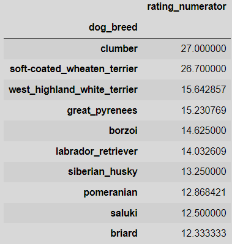

From the data above it shows that the `clumber` has the highest rating.

2.) What are the top ten breed that are the most favorite?

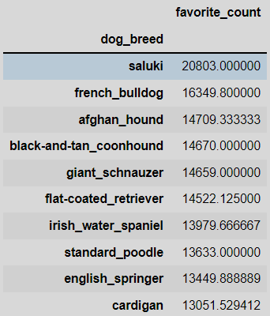

From the data above it shows that the `saluki` is the most favorite

3.) What are the top ten breed that have the highest retweet count?

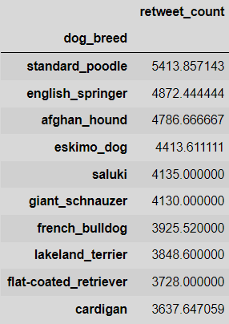

From the data above it shows that the `standard poodle` has the highest retweet count.

And from the overall top ten it shows that the `saluki` appears to be in them kudos to the saluki.

[figure not shown]

4.) What is the general trend of the WeRateDog page over the years?

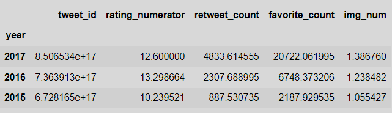

Then I plotted a graph to show the trend.

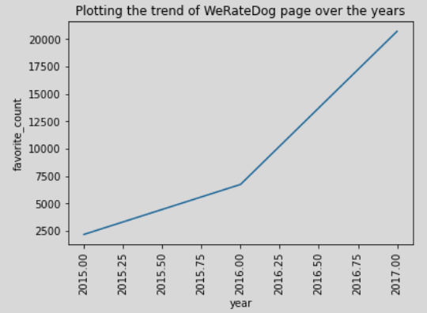

From the analysis it can be shown that has the year increased the activities in the page has also increased meaning they are gaining more attractions in their page.

### Visualizations

1.) What is the relationship between favorite_count and retweet_count?

First conducted a correlation report to see the numerical correlation between favorite_count and retweet_count

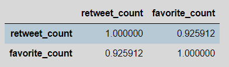

Then I plotted the graph

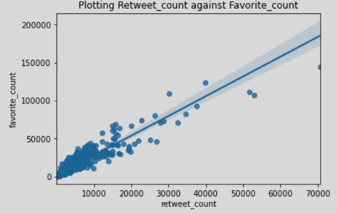

From the above scatter plot chart it shows that there is a positive relationship between them.